# Analysis

2. a specific suggestion for a plot: for each of your sampled beta vectors, normalize beta_t by its “largest” element (where largest means largest in absolute value, but you normalize by the actual value, not the absolute value, so that the normalized vector has maximum element +1). Then just plot a histogram of the resulting normalized beta values (pooled across all the samples). We should see very strong negative values are rare?

Here I use posterior means:

```r
sum(ebnorm>0)/length(ebnorm)
```

```
## [1] 0.8330297
```

```r
sum(eznorm>0)/length(eznorm)
```

```
## [1] 0.8383845
```

```r
znorm=het.norm(effectsize = z.stat)
sum(znorm>0)/length(znorm)
```

```
## [1] 0.7180483
```

```r
sum(bnorm>0)/length(bnorm)
```

```
## [1] 0.7144276
```

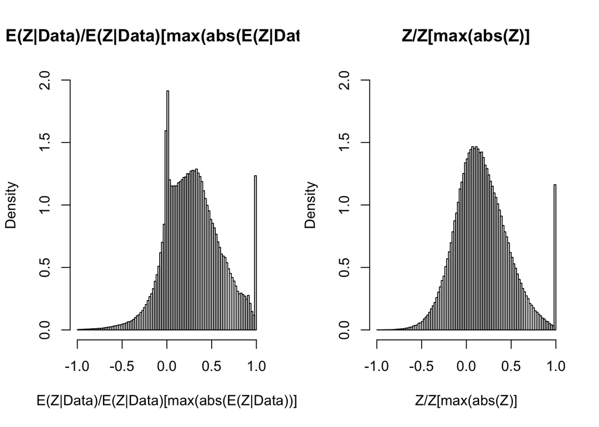

```r
par(mfrow=c(1,2))
hist(as.vector(unlist(eznorm)),main="E(Z|Data)/E(Z|Data)[max(abs(E(Z|Data))]",freq=F,xlab="E(Z|Data)/E(Z|Data)[max(abs(E(Z|Data))]",ylim=c(0,2),nclass=100)
hist(as.vector(unlist(znorm)),main="Z/Z[max(abs(Z)]",freq=F,xlab="Z/Z[max(abs(Z)]",ylim=c(0,2),nclass=100)
```

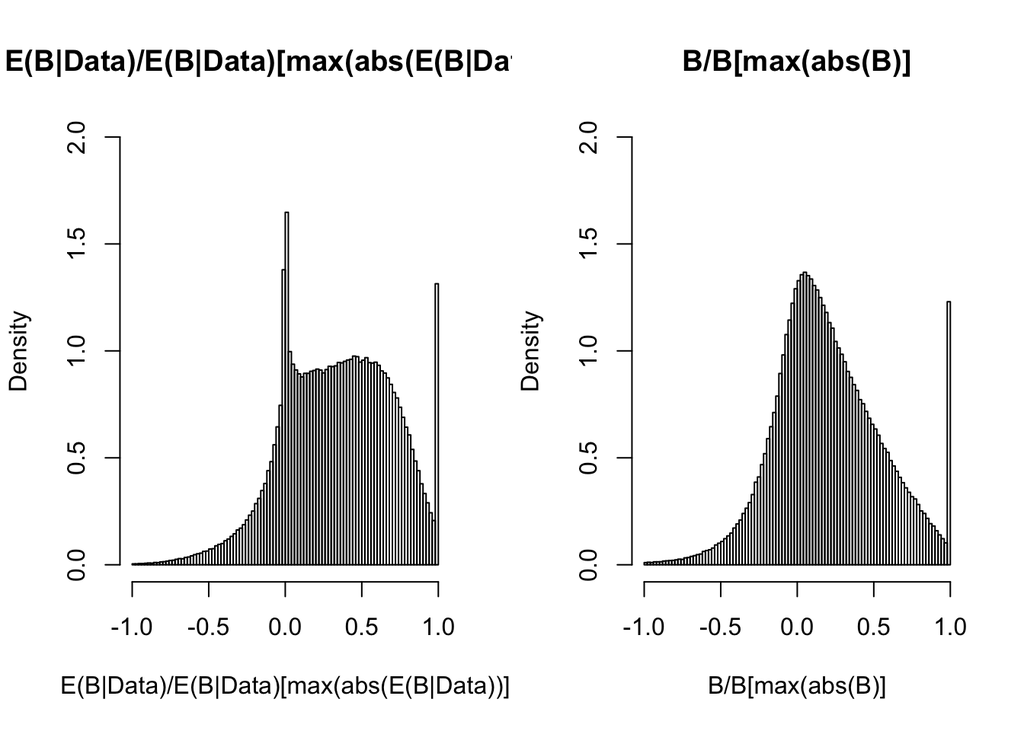

```r
par(mfrow=c(1,2))
hist(as.vector(unlist(ebnorm)),main="E(B|Data)/E(B|Data)[max(abs(E(B|Data))]",freq=F,xlab="E(B|Data)/E(B|Data)[max(abs(E(B|Data))]",ylim=c(0,2),nclass=100)
hist(as.vector(unlist(bnorm)),main="B/B[max(abs(B)]",freq=F,xlab="B/B[max(abs(B)]",ylim=c(0,2),nclass=100)
```

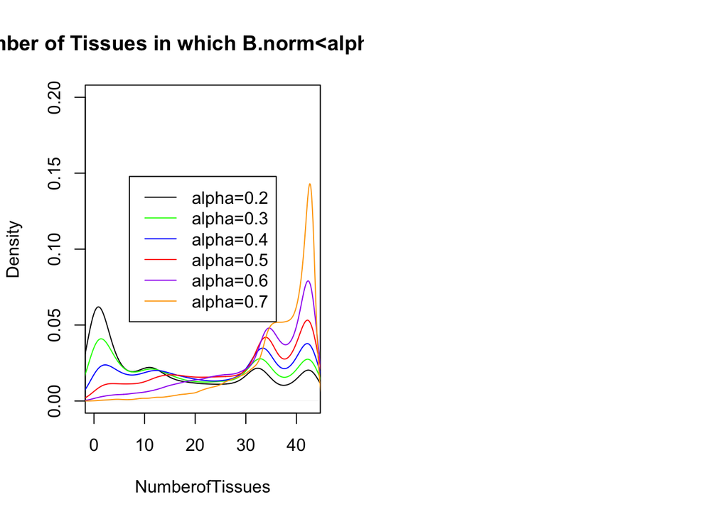

```r
het.func=function(normdat,threshold){
  apply(normdat,1,function(x){sum(x<threshold)})}


plot(density(het.func(ebnorm,threshold=0.2)),main="Number of Tissues in which B.norm<alpha*MaxB",xlab="NumberofTissues",ylim=c(0,0.2),xlim=c(0,43))
lines(density(het.func(ebnorm,threshold=0.3)),col="green")
lines(density(het.func(ebnorm,threshold=0.4)),col="blue")
lines(density(het.func(ebnorm,threshold=0.5)),col="red")
lines(density(het.func(ebnorm,threshold=0.6)),col="purple")
lines(density(het.func(ebnorm,threshold=0.7)),col="orange")
legend("center",col=c("black","green","blue","red","purple","orange"),legend=c("alpha=0.2","alpha=0.3","alpha=0.4","alpha=0.5","alpha=0.6","alpha=0.7"),lty=1)
```

Now, we might want to plot a biplot of these values vs the value used to normalize it:

```r
R=ncol(posterior.means)
maxes=t(apply(posterior.means,1,function(x){
  rep(x[which.max(abs(x))],R)
}))


max.mle=t(apply(maxz,1,function(x){
  rep(x[which.max(abs(x))],R)
}))

png("normstuffez.png")
par(mfrow=c(1,2))
plot(abs(maxes),eznorm,main="NormalizingZvsNormalized_PM",xlab="absNormalizingValue",ylab="E(Z|data)_norm",
     col=rgb(0,100,0,50,maxColorValue=255), pch=16)

plot(abs(max.mle),znorm,,main="NormalizingZvsNormalized_Zmle",ylab="Z_norm",xlab="absNormalizingValue",col=rgb(0,100,0,50,maxColorValue=255), pch=16)

dev.off()

png("normstuffez_sign.png")
par(mfrow=c(1,2))
plot(abs(maxes),ezsign,main="NormalizingZvsNormalized_PM",xlab="absNormalizingValue",ylab="E(Z|data)_norm",
     col=rgb(0,100,0,50,maxColorValue=255), pch=16)

plot(abs(max.mle),zsign,main="NormalizingZvsNormalized_Zmle",ylab="Z_norm",xlab="absNormalizingValue",col=rgb(0,100,0,50,maxColorValue=255), pch=16)
dev.off()




maxes=t(apply(posterior.betas,1,function(x){
  rep(x[which.max(abs(x))],R)
}))

max.mle=t(apply(maxb,1,function(x){
  rep(x[which.max(abs(x))],R)
}))

png("normstuffeb.png")
par(mfrow=c(1,2))
plot(abs(maxes),ebnorm,main="NormalizingBvsNormalized_PM",xlab="absNormalizingValue",ylab="E(Z|data)_norm",
     col=rgb(0,100,0,50,maxColorValue=255), pch=16)
plot(abs(max.mle),bnorm,main="NormalizingBvsNormalized_Zmle",ylab="Z_norm",xlab="absNormalizingValue",col=rgb(0,100,0,50,maxColorValue=255), pch=16)
dev.off()

png("normstuffeb_sign.png")
par(mfrow=c(1,2))
plot(abs(maxes),ebsign,main="NormalizingBvsNormalized_PM",xlab="absNormalizingValue",ylab="E(B|data)_sign",
     col=rgb(0,100,0,50,maxColorValue=255), pch=16)
plot(abs(max.mle),bsign,main="NormalizingBvsNormalized_Zmle",ylab="B_norm",xlab="absNormalizingValue",col=rgb(0,100,0,50,maxColorValue=255), pch=16)
dev.off()


png("ecdf.png")
e=ecdf(ebnorm)
plot(e,main="eCDFofBNorm")
lines(ecdf(bnorm),col="red")
legend("left",lty=1,col=c("black","red"),legend=c("E(B|Data)/E(B|Data)[which.max(abs(E(B|Data))]","B.mle/B.mle[which.max(abs(B.mle)]"))
dev.off()
```

2. as in ii) but normalize just by sign of largest element, rather than largest element. (that is, we just flip each beta vector so the largest element is positive). Again we don’ t expect to see large negative values. This preserves information about absolute size of beta, not just relative size.

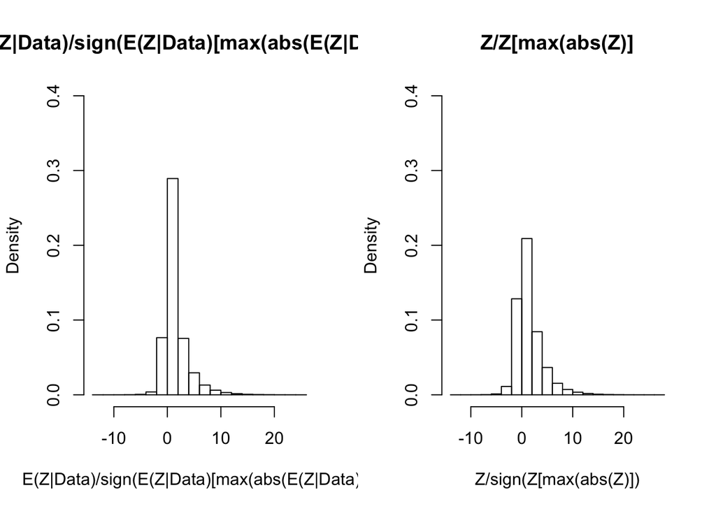

```r
het.sign=function(effectsize){
  t(apply(effectsize,1,function(x){
  x/sign(x[which.max(abs(x))])
}))}


ezsign=het.sign(effectsize = posterior.means)
zsign=het.sign(effectsize = z.stat)

ebsign=het.sign(effectsize = posterior.betas)
bsign=het.sign(effectsize = maxbetas)

par(mfrow=c(1,2))
hist(as.vector(unlist(ezsign)),main="E(Z|Data)/sign(E(Z|Data)[max(abs(E(Z|Data))])",freq=F,xlab="E(Z|Data)/sign(E(Z|Data)[max(abs(E(Z|Data))])",ylim=c(0,0.4))
hist(as.vector(unlist(zsign)),main="Z/Z[max(abs(Z)]",freq=F,xlab="Z/sign(Z[max(abs(Z)])",ylim=c(0,0.4))
```

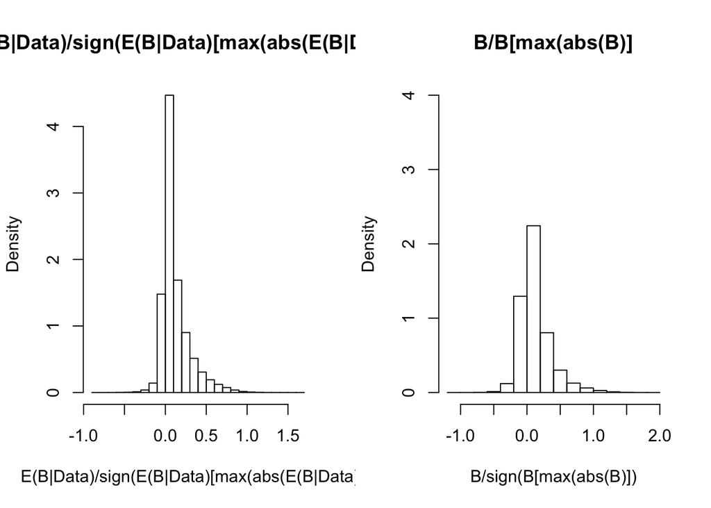

```r
par(mfrow=c(1,2))
hist(as.vector(unlist(ebsign)),main="E(B|Data)/sign(E(B|Data)[max(abs(E(B|Data))])",freq=F,xlab="E(B|Data)/sign(E(B|Data)[max(abs(E(B|Data))])")
hist(as.vector(unlist(bsign)),main="B/B[max(abs(B)]",freq=F,xlab="B/sign(B[max(abs(B)])",ylim=c(0,4))
```

Thresholding:

6. we want to avoid pitfalls of thresholding. However, as long as we keep these pitfalls in mind it might be useful to give numbers from thresholding. (eg that histogram we made that showed how many tissues each eQTL was “significant” in)

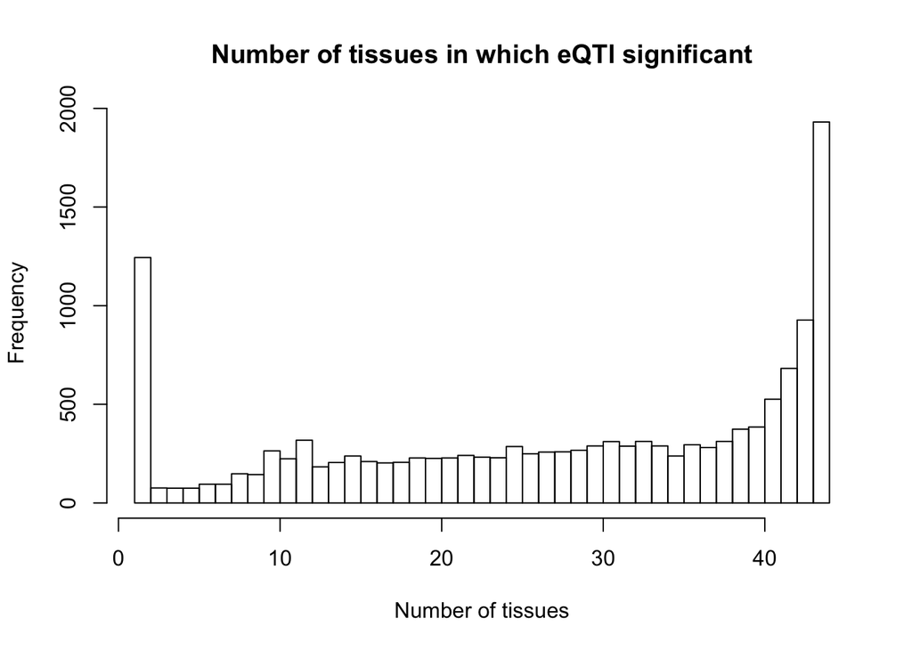

For each of your sampled beta vectors, normalize beta_t by its “largest” element (where largest means largest in absolute value, but you normalize by the actual value, not the absolute value, so that the normalized vector has maximum element +1). Then just plot a histogram of the resulting normalized beta values (pooled across all the samples). We should see very strong negative values are rare?

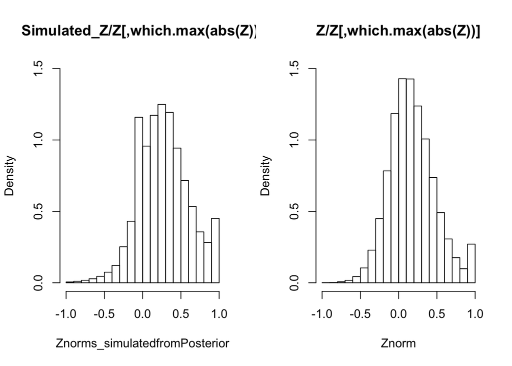

```r
hetaugust=readRDS("~/Dropbox/Aug12/simulatedmvnnormalized.rds")
max.val=readRDS("~/Dropbox/Aug12/simulatedmaxval.rds")
par(mfrow=c(1,2))
hist(unlist(as.vector(hetaugust)),main="Simulated_Z/Z[,which.max(abs(Z))]",xlab="Znorms_simulatedfromPosterior",freq=F,ylim=c(0,1.5))
hist(unlist(as.vector(znorm)),main="Z/Z[,which.max(abs(Z))]",xlab="Znorm",freq=F,ylim=c(0,1.5))
```

Here, we divide by the maximum sign value.

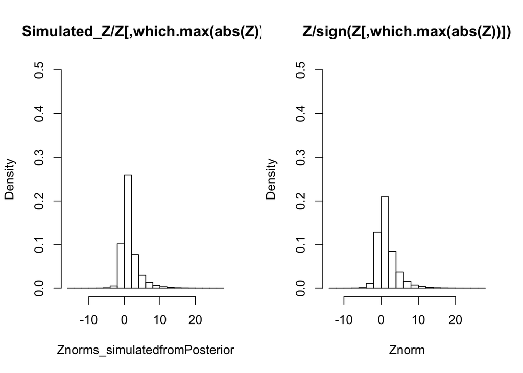

```r
hetaugust=readRDS("~/Dropbox/Aug12/simulatedmvnsign.rds")
par(mfrow=c(1,2))
hist(unlist(as.vector(hetaugust)),main="Simulated_Z/Z[,which.max(abs(Z))]",xlab="Znorms_simulatedfromPosterior",freq=F,ylim=c(0,.5))


hist(unlist(as.vector(zsign)),main="Z/sign(Z[,which.max(abs(Z))])",xlab="Znorm",freq=F,ylim=c(0,0.5))
```

Biplots of simulated values:

```r
rep.col<-function(x,n){
   matrix(rep(x,each=n), ncol=n, byrow=TRUE)
}

bi_plot_funct=function(sim,max.val,sim.array){
  j=sim
  mat.col=max.val[,j]
  a=rep.col(max.val[,j],44)
  plot(sim.array[,j,],a,main="MaxValuevsSimulatedNormalizedValue",xlab="SimulatedArrayDividedbyMaxVal",ylab="MaximumValue",col=rgb(0,100,0,50,maxColorValue=255), pch=16)
  }
```

For each simulation, we can make a biplot against the rvalue used to normalize the vector (the maxval).

```r
hetsign=readRDS("~/Dropbox/Aug12/simulatedmvnsign.rds")
hetval=readRDS("~/Dropbox/Aug12/simulatedmvnnormalized.rds")
sum(hetsign>0)/length(hetsign)
```

```
## [1] 0.7855853
```

```r
sum(hetval>0)/length(hetval)
```

```
## [1] 0.7855853
```

```r
sum(znorm>0)/length(znorm)
```

```
## [1] 0.7180483
```

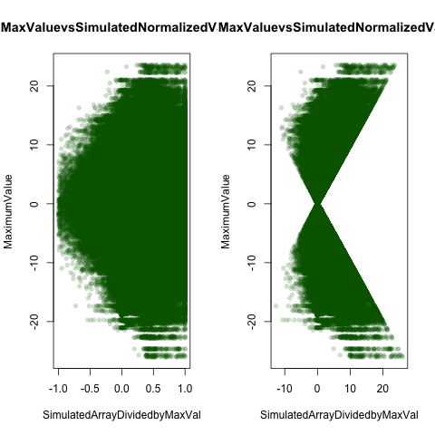

[figure not shown]

[figure not shown]

[figure not shown]

```r
png("simulatedvsmax.png")
par(mfrow=c(1,2))
bi_plot_funct(sim=5,max.val = max.val,sim.array=hetval)
bi_plot_funct(sim=5,max.val = max.val,sim.array=hetsign)

dev.off()

z.max=apply(z.stat,1,function(x){x[which.max(abs(x))]})

png("mlevsmax.png")
par(mfrow=c(1,2))
bi_plot_funcmaxz(max.val=z.max,znorm = zsign)
bi_plot_funcmaxz(max.val=z.max,znorm = znorm)
dev.off()
```

Understanding patterns of sharing:

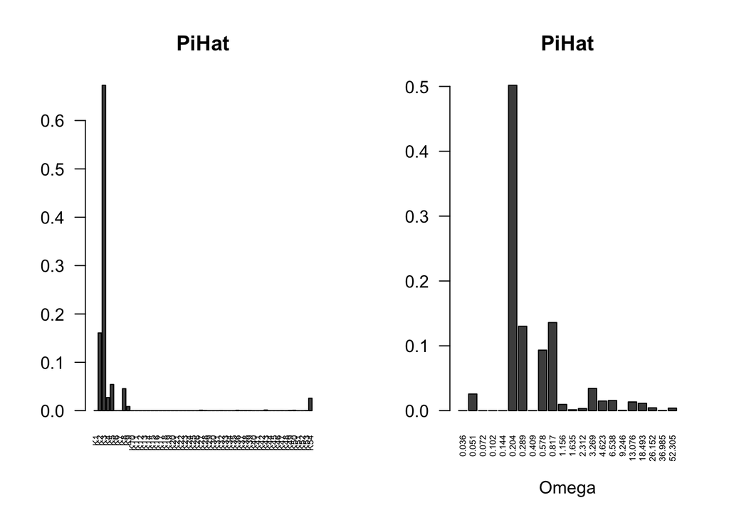

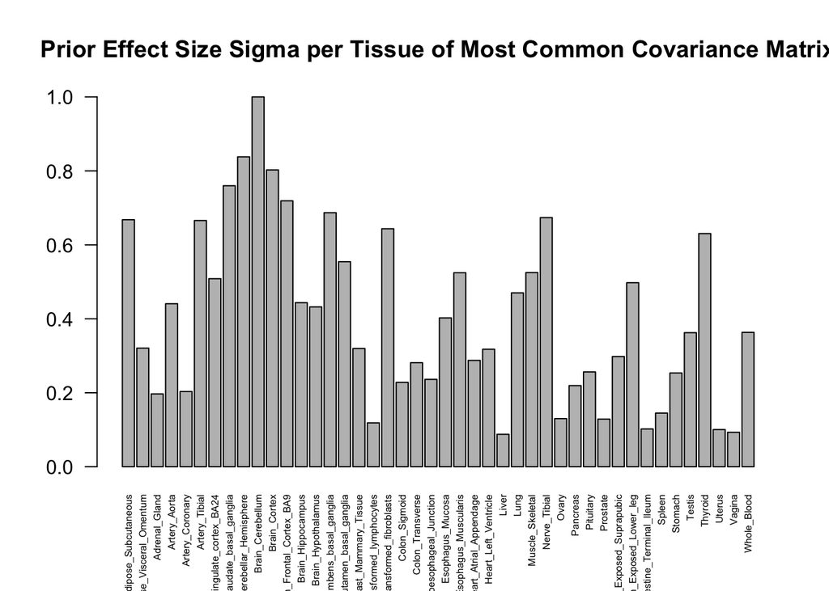

```r
barplot(diag(covmat[[num.mat[22,3]]])/max(diag(covmat[[num.mat[22,3]]])),main="Prior Effect Size Sigma per Tissue of Most Common Covariance Matrix",names=colnames(z.stat),las=2,cex.names=0.5)
```

Even though the sqrt(maximum$\omega$)is only 7, this captures the vast majority (over 95%) of the data, if we follow the principle that the max($\omega$) should be roughly $se(z)$^2+$z^2$.

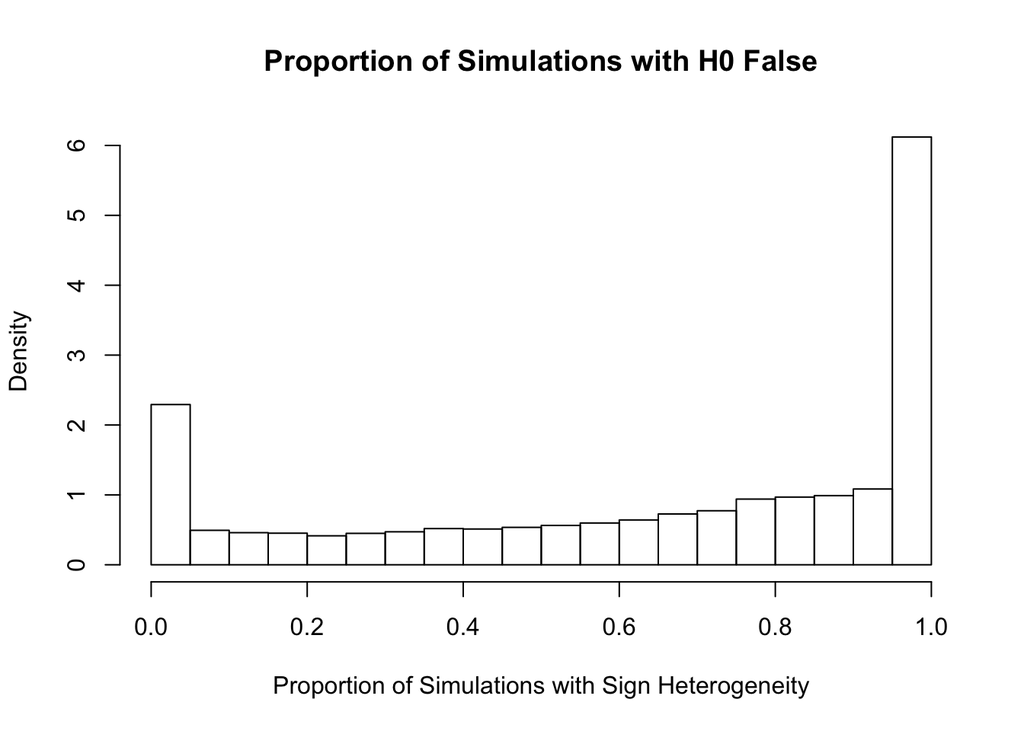

```r
dir=
heterogeneity=read.table("../Data/het.tablewithED.txt")[,1]
hist(heterogeneity,main="Proportion of Simulations with H0 False",freq=FALSE,xlab="Proportion of Simulations with Sign Heterogeneity")
```

```r
sum(heterogeneity)
```

```
## [1] 10337.48
```

```r
h=which(heterogeneity>0.5)
c=which(heterogeneity<0.5)
length(h)
```

```
## [1] 10769
```

```r
length(c)
```

```
## [1] 5211
```

```r
summary(unlist(as.vector(lfsr[h,])))
```

```
##    Min. 1st Qu.  Median    Mean 3rd Qu.    Max.
## 0.00000 0.00213 0.07410 0.14610 0.26570 0.75990
```

```r
summary(unlist(as.vector(lfsr[c,])))
```

```
##      Min.   1st Qu.    Median      Mean   3rd Qu.      Max.
## 0.0000000 0.0000000 0.0000841 0.1320000 0.0345400 1.0000000
```

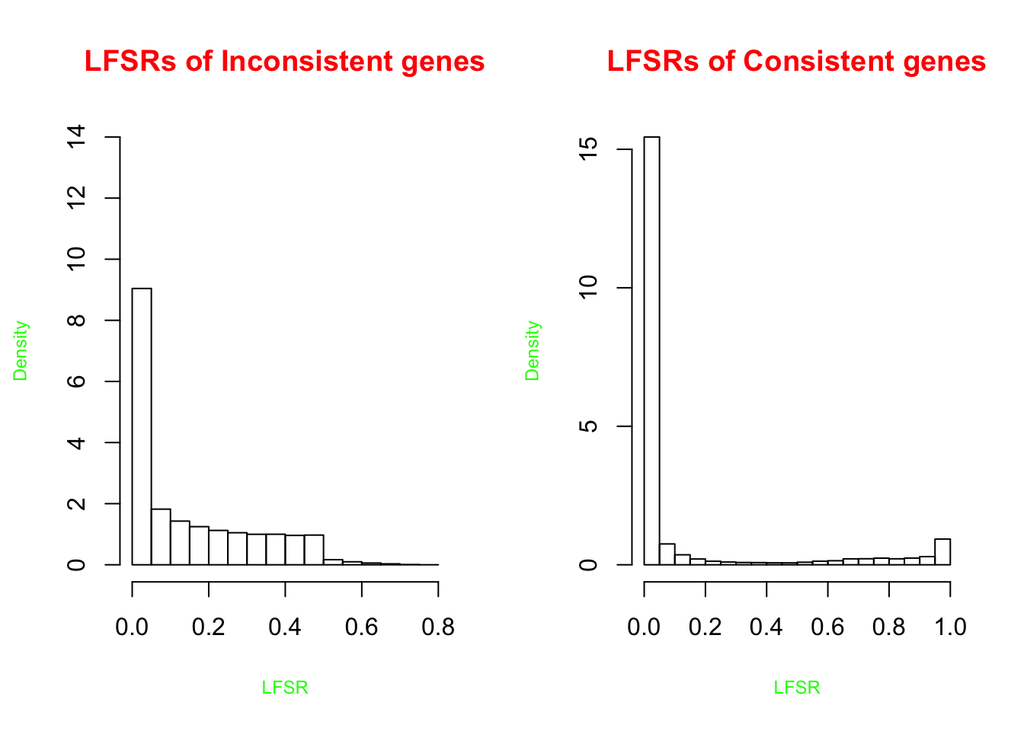

```r
par(mfrow=c(1,2))
hist(unlist(as.vector(lfsr[h,])),main=NULL,ylab=NULL,xlab=NULL,freq=FALSE,ylim=c(0,14))

title(main="LFSRs of Inconsistent genes", col.main="red",
   col.sub="blue",
    xlab="LFSR", ylab="Density",
  col.lab="green", cex.lab=0.75,ylim=c(0,14))

hist(unlist(as.vector(lfsr[c,])),main=NULL,ylab=NULL,xlab=NULL,freq=FALSE)

title(main="LFSRs of Consistent genes", col.main="red",
 col.sub="blue",
   xlab="LFSR", ylab="Density",
  col.lab="green", cex.lab=0.75)
```

But we can see that the lfsrs of the heterogeneous SNPs are consistency larger than the lfsrs of the consistent SNP, meaning that our model will alert us to their uncertainty.

Now, for each QTL I want to examine the posterior means of the tissues in which it was ‘active’ (at an lfsr threshold) and find QTL whose sign differed in at least 2 significant QTL. We restrict our analysis to only those gene snp pairs who show significance in at least one tissue:

```r
l=apply(lfsr,1,function(x){sum(x<0.05)})
sum(l!=0)
```

```
## [1] 14146
```

Now, for each QTL I want to examine the posterior means of the tissues in which it was ‘active’ (at an lfsr threshold) and find QTL whose sign differed in at least 2 significant QTL.

```r
thresh=0.05
s=sapply(seq(1:nrow(posterior.betas)),function(x){
l=lfsr[x,];p=posterior.means[x,];plow=p[which(l<thresh)];##grab only those posterior means that are 'significant'
if(length(plow)==0){return("FALSE")}##for ones who show no significants, they can't be heterogenous
else{pos=sum(plow>0);neg=sum(plow<0);pos*neg!=0}})
sum(s=="TRUE")
```

```
## [1] 3180
```

```r
hets=which(s=="TRUE")

###Now do it for univariate Z statistics

thresh=0.05
z=sapply(seq(1:nrow(maxz)),function(x){
l=lfsr[x,];p=z.stat[x,];plow=p[which(l<thresh)];##grab only those posterior means that are 'significant'
if(length(plow)==0){return("FALSE")}##for ones who show no significants, they can't be heterogenous
else{pos=sum(plow>0);neg=sum(plow<0);pos*neg!=0}})
sum(z=="TRUE")
```

```
## [1] 9655
```

```r
hets=which(z=="TRUE")
```

Now, for each snp, simulate 100 draws from mvnorm according to posterior weights; count proportion of times signs differ. This takes about 2 hours .

```r
heterogeneity=sapply(seq(1:nrow(maxz)),function(j){sim.array.generation(j,b.j.hat=maxz,s.j,covmat,pis,sim=100)})
write.table(heterogeneity,"heterogeneityindex.txt",row.names=rownames(maxz))
```

We can examine the distribution of heterogeneity.

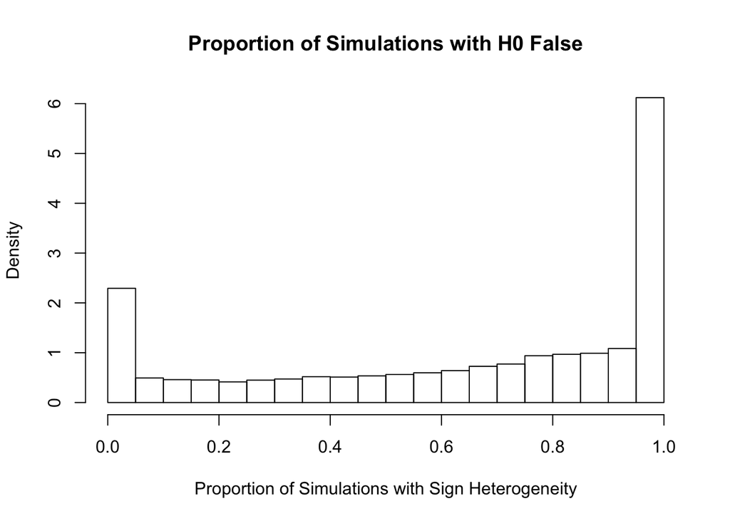

```r
heterogeneity=read.table("../Data/het.tablewithED.txt")[,1]
hist(heterogeneity,main="Proportion of Simulations with H0 False",freq=FALSE,xlab="Proportion of Simulations with Sign Heterogeneity")
```

```r
sum(heterogeneity)
```

```
## [1] 10337.48
```

If we compare with original z statistics:

```r
zhets=apply(z.stat,1,function(dat){pos=sum(dat>0);neg=sum(dat<0);pos*neg!=0})
sum(zhets)
```

```
## [1] 14557
```

```r
sum(zhets)/length(zhets)
```

```
## [1] 0.9059058
```